# Investigating variance estimation via the bootstrap for simulated double observer data

Matthew Murchie

17 June 2016

Variance estimation of abundance is a key component in distance sampling. The uncertainty associated with abundance estimates is affected by two main components:

1. *Detection function*, variation due to estimating the parameters of the detection function.
2. *Encounter rate*, variation in the number of animals observed if we were to repeat our survey.

The `dht` function, found in the package `mrds`, calculates the first component listed above using the delta method and the second component using one of three methods. See `?dht` for further details.  
In order to analyse the performance of the bootstrap it is necessary to simulate double observer data, where the true abundance and detection function is known.

## Simulating double observer data [^1]

### Region

We begin by creating a region object. For simplicity, we will consider a square survey region with a total area of 1km2. Using the `DSsim` (Marshall 2014) library in R, you can specify the coordinates of the survey region and any areas to be excluded.

```r
library(DSsim)
library(knitr)

coords <- gaps <- list()
coords[[1]] <- list(data.frame(x = c(0,1000,1000,0,0), y = c(0,0,1000,1000,0)))
gaps[[1]] <- list(data.frame(x = c(0,0,0,0,0), y = c(0,0,0,0,0)))

# create region object
region <- make.region(region.name = "study.area", units = "m",
                      coords = coords, gaps = gaps)
```

### Density

Next we create a density object by specifying a grid with a constant density, adding hotspots accordingly.

```r
pop.density <- make.density(region.obj = region, x.space = 10,
                            y.space = 10, constant = 0.5)
pop.density<- add.hotspot(pop.density, centre = c(500, 500),
                          sigma = 1000, amplitude = 0.2)
```

### Survey Design

The transects are first generated as shapefiles using the `write.transects` function [^2], which are then saved to a specified directory.  
Note that you will need to save `write.transects` as a file and use `source` to read the function into R.

```r
# specify write.transects path directory
source("C:/...")
```

```r
n_segs <- 2
lines.many <- data.frame(x   = c(rep(seq(0, 1000, len=n_segs), 4)),
                         y   = c(seq(200, 200, len=n_segs),
                                 seq(400, 400, len=n_segs),
                                 seq(600, 600, len=n_segs),
                                 seq(800, 800, len=n_segs)),
                         leg = c(rep("1", n_segs),
                                 rep("2", n_segs),
                                 rep("3", n_segs),
                                 rep("4", n_segs)))
```

Before the survey shapefiles can be generated, you will need to create an empty folder called *shapes* where the shapefiles can be saved. The object `shapefile.pathway` specifies the location of this folder.  
Ignore the warning message from `write.transects`. Here I have used the `unlink` function to ensure the *shapes* folder is empty. To check the shapefiles have been generated simply open the *shapes* folder, where you should find three new files.

```r
# specify path to shapes folder
shapefile.pathway <- "C:/.../shapes"
```

```r
unlink(shapefile.pathway, recursive = TRUE)
write.transects(lines.many, shapefile.pathway)
```

Having generated and saved the shapefiles, we supply the `make.design` function with the path to the *shapes* folder to create the survey design object.

```r
survey.design <- make.design(transect.type = "Line",
                             design.details = c("Parallel","Systematic"),
                             region = region, plus.sampling = FALSE,
                             path = shapefile.pathway)
```

### Abundance

Here we will fix the true abundance of animals to be 500. It is important to specify the argument `fixed.N = TRUE`, when using the `make.population.description` function, to ensure this exact population size is generated with each realisation.

```r
pop.description <- make.population.description(N = 500, density.obj = pop.density,
                                               region = region, fixed.N = TRUE)
```

### Analyses

The analyses object describes the model to be fitted to the distance data. Below we propose half-normal and hazard-rate models, using AIC to choose between them.

```r
ddf.analyses <- make.ddf.analysis.list(dsmodel = list(~cds(key = "hn",formula = ~1),
                                                      ~cds(key = "hr", formula = ~1)),
                                       method = "ds", criteria = "AIC", truncation = 30)
```

### Detection function

As we are simulating double observer data, we need to specify different detection functions for both observers. In both cases we select a half-normal detection function, adjusting the scale parameters associated with each.

```r
detect.1 <- make.detectability(key.function = "hn", scale.param = 20,
                               truncation = 30)

detect.2 <- make.detectability(key.function = "hn", scale.param = 5,
                               truncation = 30)
```

### Simulation

Now we are in a position to simulate double observer data. Using the `double.obs.sim` function [^3], we pull together all the survey objects created above. If `plot=TRUE`, you can simulate the detection process for each observer.

```r
# specify write.transects path directory
source("C:/...")
```

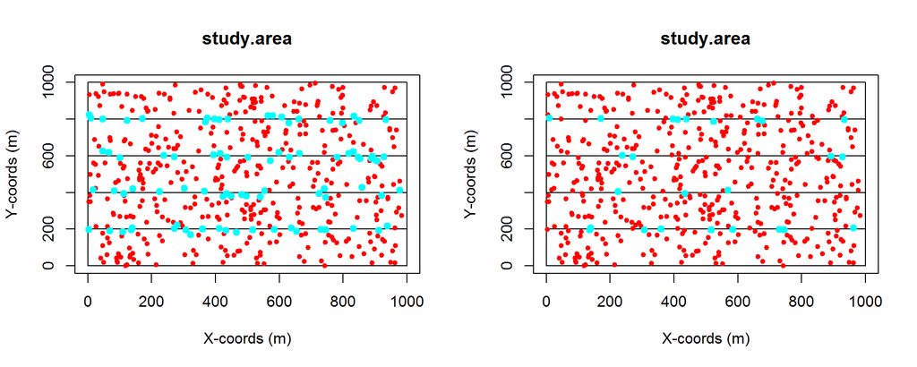

```r
# two plots in window
par(mfrow=c(1,2))

tables <- double.obs.sim(region, survey.design, pop.description, detect.1,
                         detect.2, ddf.analyses, plot=TRUE)
```

## Variance estimation via the bootstrap

To investigate variance estimation via the bootstrap, compared to methods currently implemented in `dht`, we will consider three factors:

1. the number of transects used in the survey design,
2. the number of animals in the survey region (abundance) and
3. the distribution/density of animals.

The survey region and design will be the same as simulated above, with changes being made to the factor in question.

### Survey design

We will consider survey designs of 3, 9 and 15 transects in total. For brevity, I omit the code used to generate the transects - the approach is the same as above.  
The plots given below represent each survey design.

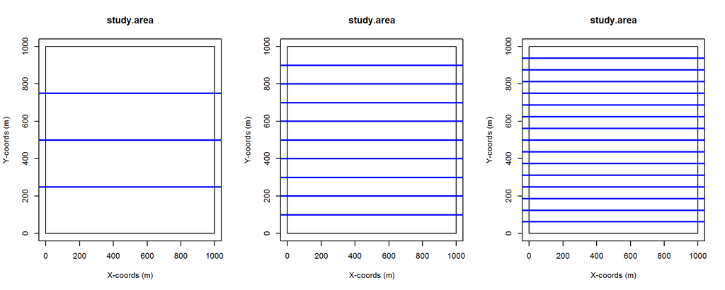

Below are the results for the survey design with only three transects.

| Method | Label | Estimate | se | cv | lcl | ucl |
| --- | --- | --- | --- | --- | --- | --- |
| Original | Total | 472.2763 | 36.43459 | 0.07714677 | 339.0433 | 657.8655 |
| Bootstrap | Total | 468.1867 | 28.56069 | 0.06100279 | 400.0000 | 511.1563 |

Below are the results for the survey design with nine transects.

| Method | Label | Estimate | se | cv | lcl | ucl |
| --- | --- | --- | --- | --- | --- | --- |
| Original | Total | 451.9145 | 28.25613 | 0.06252539 | 391.2904 | 521.9312 |
| Bootstrap | Total | 451.7609 | 26.64634 | 0.05898328 | 390.8018 | 500.0671 |

Below are the results for the survey design with fifteen transects.

| Method | Label | Estimate | se | cv | lcl | ucl |
| --- | --- | --- | --- | --- | --- | --- |
| Original | Total | 474.8077 | 24.51811 | 0.05163798 | 425.0610 | 530.3765 |
| Bootstrap | Total | 482.0957 | 25.18475 | 0.05224015 | 418.0681 | 526.1272 |

### Abundance

True abundance of 20 animals.

| Method | Label | Estimate | se | cv | lcl | ucl |
| --- | --- | --- | --- | --- | --- | --- |
| Original | Total | 22.22222 | 7.349309 | 0.3307189 | 10.57144 | 46.71335 |
| Bootstrap | Total | 33.00000 | 8.723663 | 0.2643534 | 19.44444 | 47.22222 |

True abundance of 500 animals

| Method | Label | Estimate | se | cv | lcl | ucl |
| --- | --- | --- | --- | --- | --- | --- |
| Original | Total | 451.9145 | 28.25613 | 0.06252539 | 391.2904 | 521.9312 |
| Bootstrap | Total | 451.7609 | 26.64634 | 0.05898328 | 390.8018 | 500.0671 |

True abundance of 2000 animals

| Method | Label | Estimate | se | cv | lcl | ucl |
| --- | --- | --- | --- | --- | --- | --- |
| Original | Total | 1848.220 | 20.77899 | 0.01124271 | 1800.939 | 1896.742 |
| Bootstrap | Total | 1850.824 | 20.64553 | 0.01115478 | 1807.088 | 1892.406 |

### Density

We will consider three density surfaces describing the distribution of animals within the survey region. The plots are shown below.

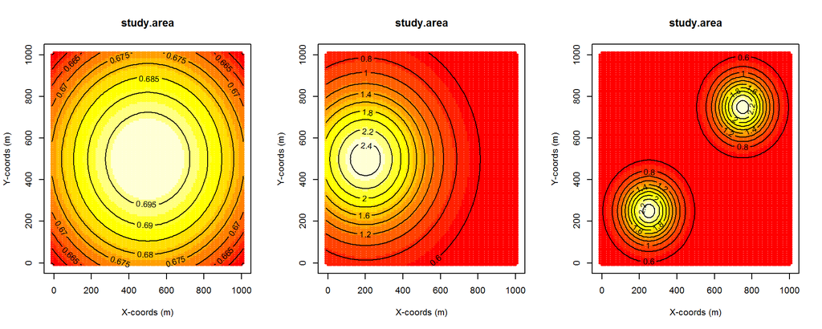

Centre

| Method | Label | Estimate | se | cv | lcl | ucl |
| --- | --- | --- | --- | --- | --- | --- |
| Original | Total | 451.9145 | 28.25613 | 0.06252539 | 391.2904 | 521.9312 |
| Bootstrap | Total | 451.7609 | 26.64634 | 0.05898328 | 390.8018 | 500.0671 |

West

| Method | Label | Estimate | se | cv | lcl | ucl |
| --- | --- | --- | --- | --- | --- | --- |
| Original | Total | 478.7607 | 54.40628 | 0.1136398 | 368.7057 | 621.6662 |
| Bootstrap | Total | 475.2174 | 52.27592 | 0.1100042 | 351.2139 | 548.8333 |

Cluster

| Method | Label | Estimate | se | cv | lcl | ucl |
| --- | --- | --- | --- | --- | --- | --- |
| Original | Total | 465.0865 | 33.97808 | 0.07305755 | 393.0664 | 550.3025 |
| Bootstrap | Total | 464.4146 | 29.44753 | 0.06340784 | 398.1851 | 522.9378 |

[^1]: Adapted from the vignette by Laura Marshall:  
    http://www.creem.st-and.ac.uk/DS.M&A/simulation/DSsimstudy.html#directory-structure-for-files-in-this-project
[^2]: write.transects() function by David Miller:  
    https://github.com/dill/spatlaugh/blob/master/write_transects.R
[^3]: double.obs.sim() function:  
    https://github.com/m-murchie/dht-bootstrap/blob/master/R/double.obs.sim.R